# Johns Hopkins University PML Project

Antonio I. M. Guerreiro

August 17, 2016

## Objective

The goal of the project is to predict the manner in which people did the barbell lift exercise.  
For additional information please see:  
http://groupware.les.inf.puc-rio.br/har (see the section on the Weight Lifting Exercise Dataset).  
Training data from:  
https://d396qusza40orc.cloudfront.net/predmachlearn/pml-training.csv  
Quizz data from:  
https://d396qusza40orc.cloudfront.net/predmachlearn/pml-testing.csv

## Required Libraries

I use the “caret” package and, as random forests are quite computer intensive,  
I also use the “doMC” package to run several cores on my machine.  
It’s very easy to install and use on Linux and OS X. http://topepo.github.io/caret/parallel.html

```r
library(caret)
library(doMC)
```

## Preparing a tidy data set

This is my way to get a tidy data set:

- remove all empty or with NAs columns
- keep only movement related columns plus “user_name” and “classe”.

```r
pdat<-read.csv("pml-training.csv", stringsAsFactors=FALSE, na.strings=c("","NA"))
pdat<-pdat[ , apply(pdat, 2, function(x) !any(is.na(x)))]
pdat<-subset(pdat,select=-c(X,new_window,num_window,raw_timestamp_part_1,raw_timestamp_part_2,cvtd_timestamp))
pdat$user_name <- as.factor(pdat$user_name); pdat$classe <- as.factor(pdat$classe)
```

This yields a tidy data set with 54 columns and 19622 rows.

## Some exploratory data analysis…

Just curious to see if one user performs better by creating a spineplot…

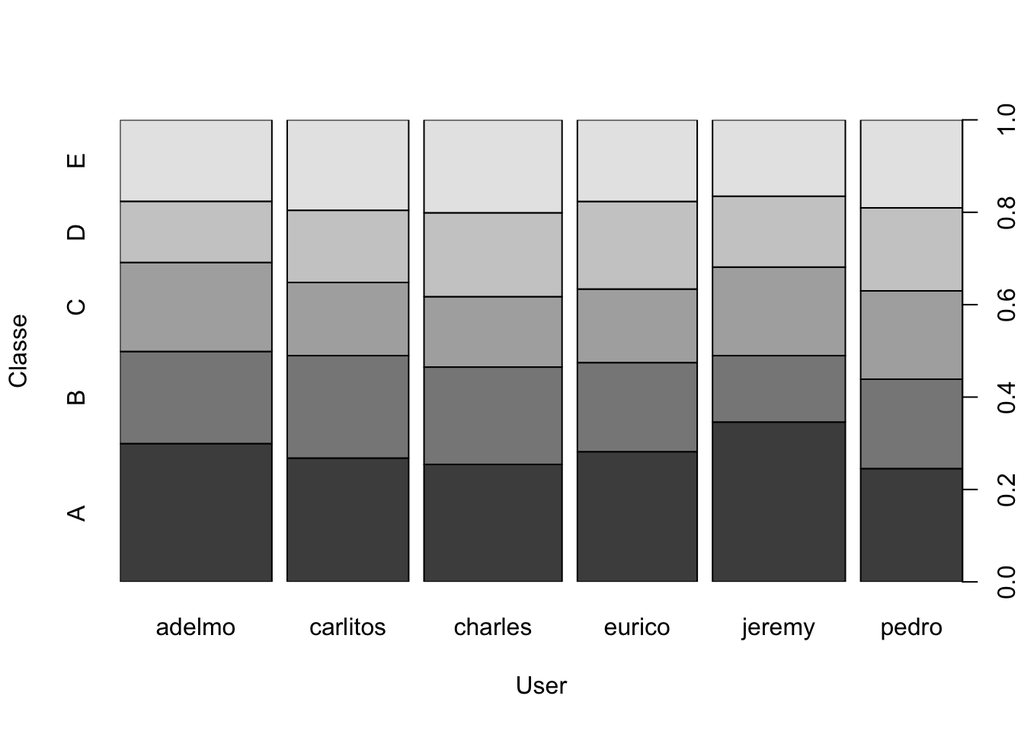

```r
plot(pdat$user_name, pdat$classe, xlab="User", ylab="Classe")
```

## Splitting the project data for building & evaluation of the model

```r
inTrain <- createDataPartition(y = pdat$classe, p = 0.7, list = FALSE)
train_data <- pdat[inTrain,]; test_data <- pdat[-inTrain,]
```

## Fitting first with the caret “rpart” method

“classe” is a factor with 5 levels so I try first a quick recursive partitioning method for classification.  
I include all features. It uses random sampling with replacement (bootstrap).  
Try no preprocessing as it’s not a linear model.

```r
modFit_rpart <- train(classe ~ ., data = train_data, method = "rpart")
modFit_rpart
```

```
## CART
##
## 13737 samples
##    53 predictor
##     5 classes: 'A', 'B', 'C', 'D', 'E'
##
## No pre-processing
## Resampling: Bootstrapped (25 reps)
## Summary of sample sizes: 13737, 13737, 13737, 13737, 13737, 13737, ...
## Resampling results across tuning parameters:
##
##   cp          Accuracy   Kappa
##   0.03458448  0.4981975  0.34581783
##   0.06001424  0.4180334  0.21602359
##   0.11443393  0.3198937  0.05828219
##
## Accuracy was used to select the optimal model using  the largest value.
## The final value used for the model was cp = 0.03458448.
```

The accuracy is very low even on the training part of the data set! What about performance on the test set?

```r
pred <- predict(modFit_rpart, test_data)
confusionMatrix(pred, test_data$classe)
```

```
## Confusion Matrix and Statistics
##
##           Reference
## Prediction    A    B    C    D    E
##          A 1520  476  467  429  168
##          B   32  385   35  167  149
##          C  121  278  524  368  272
##          D    0    0    0    0    0
##          E    1    0    0    0  493
##
## Overall Statistics
##
##                Accuracy : 0.4965
##                  95% CI : (0.4837, 0.5094)
##     No Information Rate : 0.2845
##     P-Value [Acc > NIR] : < 2.2e-16
##
##                   Kappa : 0.3419
##  Mcnemar's Test P-Value : NA
##
## Statistics by Class:
##
##                      Class: A Class: B Class: C Class: D Class: E
## Sensitivity            0.9080  0.33802  0.51072   0.0000  0.45564
## Specificity            0.6343  0.91930  0.78617   1.0000  0.99979
## Pos Pred Value         0.4967  0.50130  0.33525      NaN  0.99798
## Neg Pred Value         0.9455  0.85265  0.88385   0.8362  0.89074
## Prevalence             0.2845  0.19354  0.17434   0.1638  0.18386
## Detection Rate         0.2583  0.06542  0.08904   0.0000  0.08377
## Detection Prevalence   0.5200  0.13050  0.26559   0.0000  0.08394
## Balanced Accuracy      0.7711  0.62866  0.64845   0.5000  0.72771
```

## Fitting a random forest model using all the features of the training tidy data set

So let’s try a more powerfull method: random forests. I use 5 cores on a mac pro with 20GB RAM.

```r
registerDoMC(cores = 5)
```

I use the defaults for the method, so it’s a random sampling with replacement (bootstrap), and all features.

```r
modFit_rf <- train(classe ~ ., data = train_data, method = "rf")
modFit_rf
```

```
## Random Forest
##
## 13737 samples
##    53 predictor
##     5 classes: 'A', 'B', 'C', 'D', 'E'
##
## No pre-processing
## Resampling: Bootstrapped (25 reps)
## Summary of sample sizes: 13737, 13737, 13737, 13737, 13737, 13737, ...
## Resampling results across tuning parameters:
##
##   mtry  Accuracy   Kappa
##    2    0.9866649  0.9831258
##   29    0.9892326  0.9863753
##   57    0.9804489  0.9752581
##
## Accuracy was used to select the optimal model using  the largest value.
## The final value used for the model was mtry = 29.
```

## Evaluating out of sample error using the tidy data set part kept for testing

```r
pred <- predict(modFit_rf, test_data)
confusionMatrix(pred, test_data$classe)
```

```
## Confusion Matrix and Statistics
##
##           Reference
## Prediction    A    B    C    D    E
##          A 1673    8    0    0    0
##          B    1 1128    4    0    1
##          C    0    3 1019   10    1
##          D    0    0    3  954    3
##          E    0    0    0    0 1077
##
## Overall Statistics
##
##                Accuracy : 0.9942
##                  95% CI : (0.9919, 0.996)
##     No Information Rate : 0.2845
##     P-Value [Acc > NIR] : < 2.2e-16
##
##                   Kappa : 0.9927
##  Mcnemar's Test P-Value : NA
##
## Statistics by Class:
##
##                      Class: A Class: B Class: C Class: D Class: E
## Sensitivity            0.9994   0.9903   0.9932   0.9896   0.9954
## Specificity            0.9981   0.9987   0.9971   0.9988   1.0000
## Pos Pred Value         0.9952   0.9947   0.9864   0.9937   1.0000
## Neg Pred Value         0.9998   0.9977   0.9986   0.9980   0.9990
## Prevalence             0.2845   0.1935   0.1743   0.1638   0.1839
## Detection Rate         0.2843   0.1917   0.1732   0.1621   0.1830
## Detection Prevalence   0.2856   0.1927   0.1755   0.1631   0.1830
## Balanced Accuracy      0.9988   0.9945   0.9951   0.9942   0.9977
```

It seems rather good! So I have applied this model to the Prediction Quiz 20 test cases.

## Predicting on assignment data

```r
qdat<-read.csv("pml-testing.csv", stringsAsFactors=FALSE, na.strings=c("","NA"))
qdat<-qdat[ , apply(qdat, 2, function(x) !any(is.na(x)))]
qdat<-subset(qdat,select=-c(X,new_window,num_window,raw_timestamp_part_1,raw_timestamp_part_2,cvtd_timestamp))
qdat$user_name <- as.factor(qdat$user_name)
pred <- predict(modFit_rf, qdat)
pred
```

```
##  [1] B A B A A E D B A A B C B A E E A B B B
## Levels: A B C D E
```

I obtain 100 % accuracy on assignment data! Based on Quizz grade.

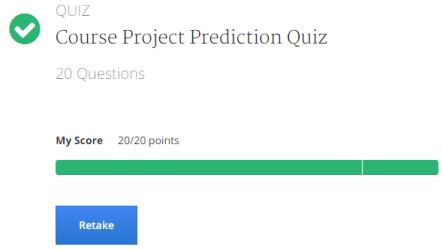

Quizz Figure

## Next steps (if more time)

- Identify correlated predictors to reduce the model complexity…
- Remove non important features…

```r
rfImp <- varImp(modFit_rf)
rfImp
```

```
## rf variable importance
##
##   only 20 most important variables shown (out of 57)
##
##                      Overall
## roll_belt             100.00
## pitch_forearm          63.71
## yaw_belt               55.33
## magnet_dumbbell_z      45.73
## magnet_dumbbell_y      44.69
## pitch_belt             44.39
## roll_forearm           38.52
## accel_dumbbell_y       23.68
## roll_dumbbell          20.57
## magnet_dumbbell_x      19.08
## accel_forearm_x        18.16
## magnet_belt_z          17.91
## accel_belt_z           14.92
## accel_dumbbell_z       14.90
## total_accel_dumbbell   14.70
## magnet_forearm_z       14.19
## magnet_belt_y          14.05
## roll_arm               13.12
## gyros_belt_z           12.15
## yaw_arm                11.71
```